# IODS course project

# Dimensionality reduction techniques

**Principal Component Analysis**

The ‘human’ dataset originates from the United Nations Development Programme. For more information see [their data page](http://hdr.undp.org/en/content/human-development-index-hdi) and the [technical notes](http://hdr.undp.org/sites/default/files/hdr2015_technical_notes.pdf) about calculating the human development indices.

The variable names in the data have been shortened, two new variables have been computed and only part of the original variables was kept.

See the structure of our data set, which now contains 155 obsservations of 8 variables.

```r
human_ <- read.csv(file="data/human.csv")
str(human_)
```

```
## 'data.frame':    155 obs. of  8 variables:
##  $ sedu_ratio: num  1.007 0.997 0.983 0.989 0.969 ...
##  $ lab_ratio : num  0.891 0.819 0.825 0.884 0.829 ...
##  $ life_exp  : num  81.6 82.4 83 80.2 81.6 80.9 80.9 79.1 82 81.8 ...
##  $ exp_edu   : num  17.5 20.2 15.8 18.7 17.9 16.5 18.6 16.5 15.9 19.2 ...
##  $ gni_c     : int  64992 42261 56431 44025 45435 43919 39568 52947 42155 32689 ...
##  $ mat_mort  : int  4 6 6 5 6 7 9 28 11 8 ...
##  $ ad_birth  : num  7.8 12.1 1.9 5.1 6.2 3.8 8.2 31 14.5 25.3 ...
##  $ repr_parl : num  39.6 30.5 28.5 38 36.9 36.9 19.9 19.4 28.2 31.4 ...
```

- “sedu_ratio” = Ratio of females/males with at least secondary education
- “lab_ratio” = Ratio of females/males in the labour force
- “life_exp” = Life expectancy at birth
- “exp_edu” = Expected years of schooling
- “gni_c” = Gross National Income per capita
- “mat_mort” = Maternal mortality ratio
- “ad_birth” = Adolescent birth rate
- “repr_parl” = Percetange of female representatives in parliament

We now visualize an overview of the data and the correlation matrix to get some insight on the relationships between the variables.

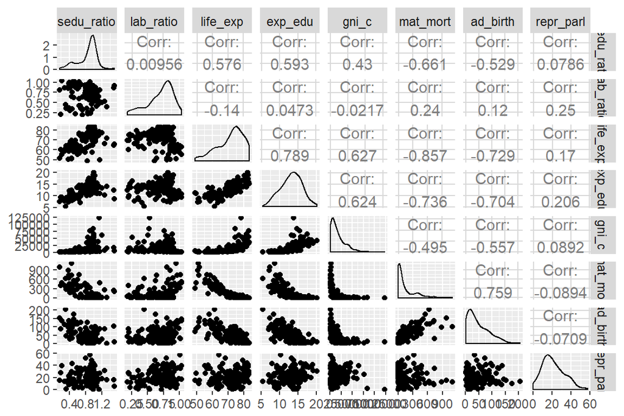

```r
library(GGally)
library(dplyr)
library(corrplot)
# visualize the 'human_' variables
ggpairs(human_)
```

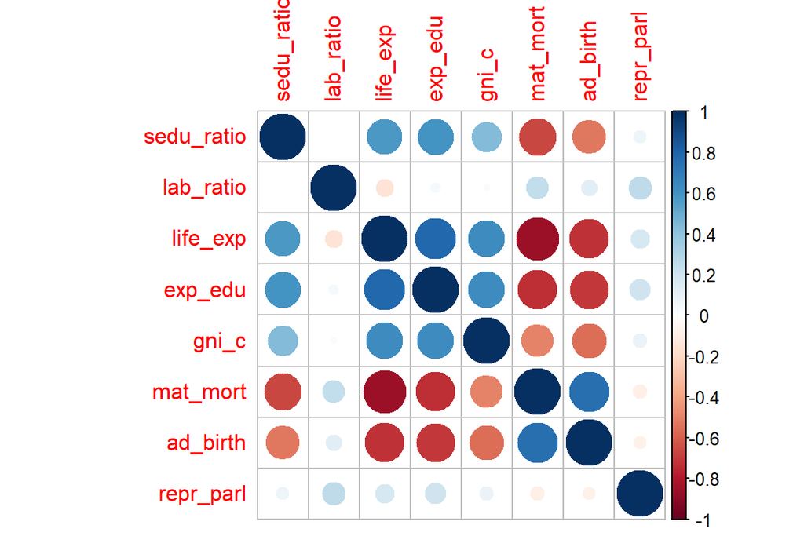

```r
# compute the correlation matrix and visualize it with corrplot
cor(human_) %>% corrplot
```

We can see, for example, a quite strong positive correlation between life_exp and exp_edu: in countries where the life expectancy is higher people also tend to go to school longer. The strong negative correlation between life_exp and mat_mort is easy to believe: if the maternity mortality ratio is higher then the life expectancy is lower. The correlation matrix also suggests that countries with high maternity mortality ratio have fewer expected years of schooling and low ratio of females vs male with at least secondary education.

We now first perform Principal Component Analysis (PCA) on the not standardized data and compare it with the results on the standardized data. Let us look at the variability captured by the principal components and the biplot displaying the observations by the first two principal components (PC1 and PC2), along with arrows representing the original variables.

```r
pca_ns <- prcomp(human_)
# create and print out a summary of pca_human
ns <- summary(pca_ns)
# rounded percetanges of variance captured by each PC
pca_pr <- round(100*ns$importance[2, ], digits = 1)
# print out the percentages of variance
pca_pr
```

```
## PC1 PC2 PC3 PC4 PC5 PC6 PC7 PC8
## 100   0   0   0   0   0   0   0
```

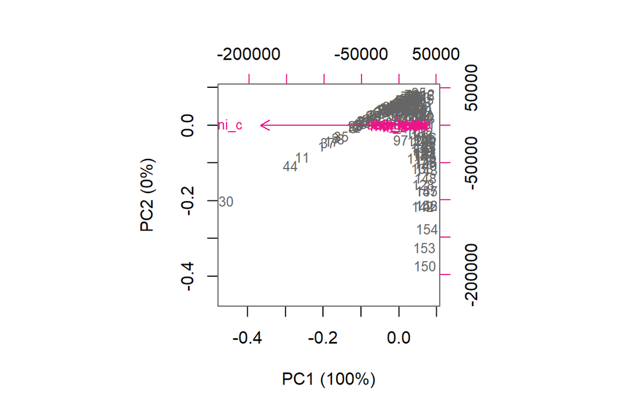

```r
# create object pc_lab to be used as axis labels
pc_lab <- paste0(names(pca_pr), " (", pca_pr, "%)")
# draw a biplot
biplot(pca_ns, cex = c(0.8, 0.8), col = c("grey40", "deeppink2"), xlab = pc_lab[1], ylab = pc_lab[2])
```

One principal component captures all the variability, something is wrong. This principal component corresponds to the variable -gni_c (Gross National Income per capita).

We now standardize the data and repeat the PCA, showing again the variability captured by the principal components and the biplot.

```r
human_std <- scale(human_)
pca_s <- prcomp(human_std)
# create and print out a summary of pca_human
s <- summary(pca_s)
# rounded percetanges of variance captured by each PC
pca_prs <- round(100*s$importance[2, ], digits = 1)
# print out the percentages of variance
pca_prs
```

```
##  PC1  PC2  PC3  PC4  PC5  PC6  PC7  PC8
## 53.6 16.2  9.6  7.6  5.5  3.6  2.6  1.3
```

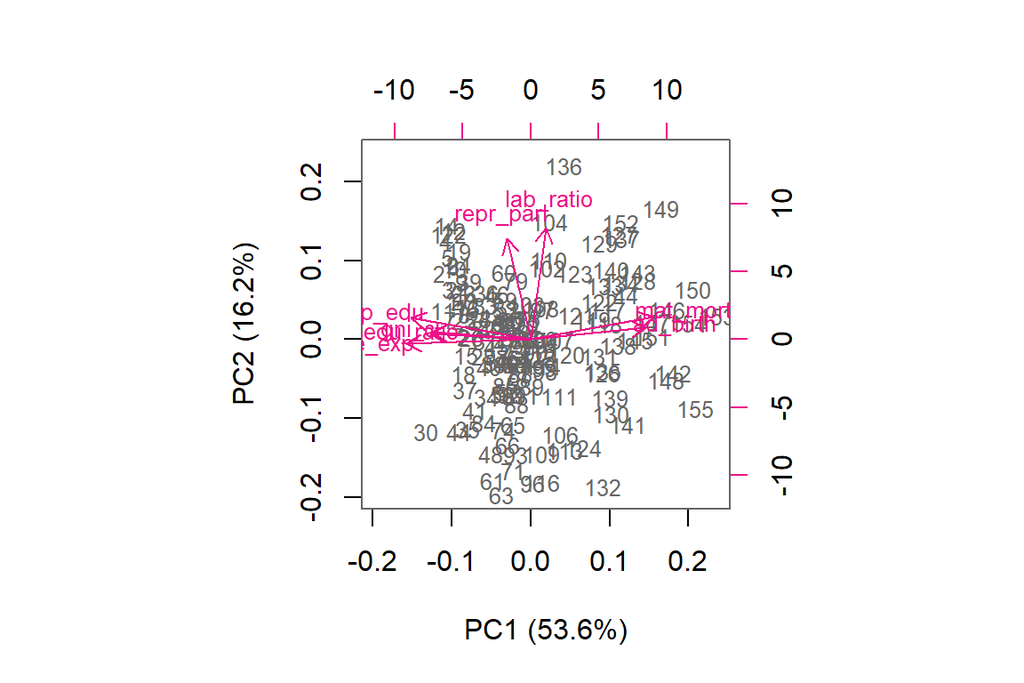

```r
# create object pc_lab to be used as axis labels
pc_labs <- paste0(names(pca_prs), " (", pca_prs, "%)")
# draw a biplot
biplot(pca_s, cex = c(0.8,0.8), col = c("grey40", "deeppink2"), xlab = pc_labs[1], ylab = pc_labs[2])
```

The results are now very different: the first principal component (PC1) captures 53.6% of the variablity and the second one (PC2) 16.2%. The variables mat_mort and ad_birth have high positive correlation with PC1, wereas the variables exp_edu, life_exp, sedu_ratio and gni_c have high negative correlation with PC1. Therefore it seems that life expectancy, maternal mortality, adolescent birth ratio, the expected years of education (especially for females) and the gross national income per capita are the most important criteria for assessing the development of a country.

Clearly it is good to standardize the data before performing PCA, since it is sensitive to the relative scaling of the original features and assumes that features with larger variance are more important than features with smaller variance. As we have seen, one can get very different result if the data is not standardized.

**Multiple Correspondence Analysis**